# MT5763 Group Project - Data Analysis (Python)

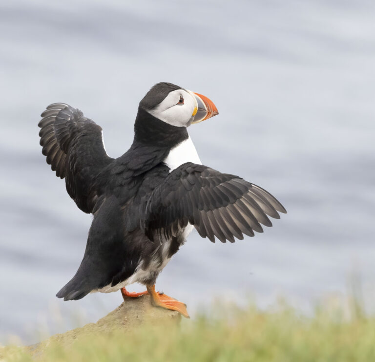

## Bird Biodiversity Analysis Toolkit

A complete, end-to-end workflow for collecting, visualising and analysing UK bird observation data.

This project integrates a real-time Shiny application with Python-based statistical analysis, including jackknife estimation, bootstrap regression and simulation-based hypothesis testing.

This repository accompanies the Shiny application (repo can be found [here](https://github.com/mt5763standrews/shiny-app-puffin)) and reproducible code for the MT5763 Software for Data Analysis module.

## Overview

This project was developed as part of the MT5763 Software for Data Analysis module at the University of St Andrews.

We built a full analysis pipeline using both R (for the Shiny App) and Python (for data analysis).

All results shown in the report come from our reproducible .qmd file.

What the project does: * Fetches bird occurrence data via [GBIF API](https://techdocs.gbif.org/en/openapi/) * Displays observations on a live, interactive map * Exports data for analysis * Applies jackknife, bootstrap, and randomisation-based methods * Tests for species differences in geographic location * Produces polished figures and clear interpretations

Why this matters: * Biodiversity monitoring relies on high-quality tools * The pipeline demonstrates correct application of resampling methods * The analysis helps understand whether species prefer different regions

## Authors

This project was created by MT5763 Group Puffins

All group members contributed to Tasks 1–4 as required by the module specification.

## Usage instructions

Here is how to run each component of the toolkit.

### Run the Shiny App

Can be found in the following [repository](https://github.com/mt5763standrews/shiny-app-puffin) and run it with

`{r} shiny::runApp("app/")`

Both open: * An interactive map of bird sightings * A data summary tab * A table of occurrences * Buttons to load and download filtered data

### Data for analysis

All data used in this project was downloaded through our Shiny App using the GBIF API.

The dataset includes two bird species: * Blue Tit (Cyanistes caeruleus) * European Robin (Erithacus rubecula)

The downloaded dataset is saved in the repository under:

`{bash} Data/GBIF_Erithacus_rubecula_2025.csv`

and

`{bash} Data/GBIF_Cyanistes_caeruleus_2025.csv`

This file contains the exact data used for Tasks 2–4 in our statistical analysis.

#### Download date

The dataset was retrieved on: * 25 November 2025

#### What the data contains

- 300 Blue Tit observations
- 300 European Robin observations
- - Geographic coordinates (latitude, longitude)
- - Measurement uncertainty
- - Metadata from GBIF’s occurrence records

### Run the Quarto Report

```bash
quarto render analysis/MT5763_Puffins.qmd
```

This will generate the full .html report containing: * Jackknife SE results * Regression outputs * Randomisation test null distributions * Bootstrap distributions and confidence intervals * All figures used in the final submission

### Example Python snippet

```python
from analysis.randomisation import randomisation_test_fast

T_obs, p_fast = randomisation_test_fast(data, n_permutations=1000)
print("Observed T:", T_obs)
print("Fast p-value:", p_fast)
```

## Installation instructions

### Requirements

- Python 3.10+
- Quarto
- R 4.0+ (for running the Shiny APP)

### Python packages:

You can install the required Python libraries using either **pip** or **conda**, depending on your setup:

**Using pip:**

```bash
pip install numpy pandas matplotlib statsmodels
```

**Using conda:**

```bash
conda install numpy pandas matplotlib statsmodels
```

Both options will give you all the dependencies needed to run the analysis and render the Quarto report.

### Install R dependencies (for running the Shiny APP)

```r
install.packages(c("shiny", "leaflet", "httr", "jsonlite"))
```

That’s it!